# R-Markdown

2021-05-14

## Markdown Nedir ?

> R Markdown notlar,kodlar,formüller,grafikler ve resimler ile birlikte çalışma imkanı sağlayan, **.Rmd** uzantılı, bir R kütüphanesidir. **R Markdown,** herhangi bir HTML veya LaTeX kodunu bilmek zorunda kalmadan veya zor biçimlendirme sorunlarıyla uğraşmak zorunda kalmadan, biçimlendirilmiş bir HTML, PDF veya Word dosyası oluşturmak için R kodunun markdown metni ile birlikte çalışmasını sağlar.

> Rmarkdown’da hem bilgisayar kodu hem de anlatılar aynı belgede olduğundan ve sonuçlar otomatik olarak kaynak koddan üretildiğinden, yeniden üretilebilirlik için tasarlanmıştır. R Markdown birçok statik ve dinamik/etkileşimli çıktı formatını destekler.(Word,html,pdf,books,dashboard,shiny,scientific articles vs.)

R Markdown tanıtımına [buradan](https://rmarkdown.rstudio.com) erişebilirsiniz.

R Markdown belgesinin üç temel bileşeni vardır:

- meta veriler
- metin
- kod (chunk)

> R Markdown raporunda gördüğünüz ilk birkaç satır YAML olarak bilinir. Üç çizgi çifti arasında yer alan YAML (YAML, insan tarafından okunabilen bir veri serileştirme dilidir) sözdizimi Meta veriyi ifade eder. Bu satırlar, nihai raporun başında genel bir başlık üretecektir.

### Markdown Nasıl Çalışır ?

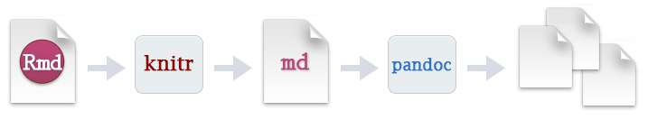

> R Markdown ile belge oluşturmak, markdown ve R kodu parçalarının bir kombinasyonunu içeren bir **.Rmd** dosyası ile başlar. **Knitr** tüm R kodu parçalarını çalıştıran ve çıktı ile yeni bir etiketleme (.md) belgesi oluşturan .Rmd dosyasını besler.

> Knitr tarafından oluşturulan etiketleme dosyası daha sonra bitmiş bir web sayfası, **PDF,** **MS Word** belgesi, **slayt** gösterisi, çalışma kağıdı, kitap, gösterge paneli, paket skeç veya başka bir format oluşturmaktan sorumlu olan pandoc tarafından işlenir ve bitmiş bir rapor oluşturulabilir.

Çıktı Formatları;

[figure not shown]

### Çalışma Ortamı Ayarlama

> Bir R Markdown dosyası oluşturmak için **File > New File > R Markdown** öğesini seçebilir veya RStudio penceresinin sol üst köşesinde yeni bir belge oluşturmak için kısayolu seçebilirsiniz. Size bir HTML, PDF veya Word belgesi oluşturma seçeneği sunulacak; ancak, R Markdown belgenizi oluşturduktan sonra bu seçenekler arasında sorunsuz bir şekilde geçiş yapmanıza izin verir.

### Chunk İşlemi

> R çıktısını belgelere dönüştürmek ya da sadece gösterim amacıyla kodu görüntülemek için bir araç olarak kullanılabilir. R studio çalışma sayfasının sağ üst kısmında yer alan sekmesinden veya **Ctrl + Alt +I** (windows) kısayolu ile chunk eklenir.

Chunk çıkışı birçok knitr seçeneğiyle özelleştirilebilir. Başlıca kullanılan özelleştirme fonksiyonları;

- **echo=FALSE** kodu gizler sonuçları gösterir.
- **eval=FALSE** kodu gösterir ancak değerlendirmez.
- **results=‘hide’** sonuçları gizler fakat kodu gösterir.
- **include=FALSE** kodu değerlendirir ancak kod veya çıktı göstermez.
- **warning=FALSE** ve **message=FALSE** paketleri yüklerken üretilen mesajları kaldırmak için kullanışlıdır.

Chunk çıktısı için kullanılabilecek diğer fonksiyonlara [Markdown dokümanından](https://www.rstudio.com/wp-content/uploads/2015/03/rmarkdown-reference.pdf) erişebilirsiniz. erişebilirsiniz.

**İlgili linkler;**

https://www.rstudio.com/wp-content/uploads/2015/03/rmarkdown-reference.pdf

https://rmarkdown.rstudio.com/articles_intro.html

https://rmarkdown.rstudio.com